# (Fast) Introduction to R and Population Genetics

Felipe Ferrão  
08/27/2018

### Outline

- Introduction
- Basic Syntax
- Objects Types
- Importing and exporting data
- Subsetting
- Population genetic
- Homework

### Motivation ?

- Axis of Awesome: 4 Four Chord Song

https://www.youtube.com/watch?v=5pidokakU4I

### What is R ?

- Programming language
- Free
- Open Source
- Statistics
- Modeling
- Graphics
- Bioinformatic
- …

https://www.r-project.org/

https://www.rstudio.com/

### R as a caculator

Sum

```r
4+4
```

```
[1] 8
```

Divide

```r
3/3
```

```
[1] 1
```

Logaritm

```r
log(10)
```

```
[1] 2.302585
```

Exponential

```r
exp(2.3025)
```

```
[1] 9.999149
```

### R as a caculator

Derivatives in R

```r
D(expression(x^2), "x")
```

```
2 * x
```

### Help and packages

You can ask for help

```r
help(sum)
?seq
```

- You can access basic function (e.g, sum, mean, variance and others) that come with `base R`.
- For more complex or specific task you can use functions/data sets that have been created and that are implemented in **packages**.

```r
install.packages("packagename")
```

### Help and packages

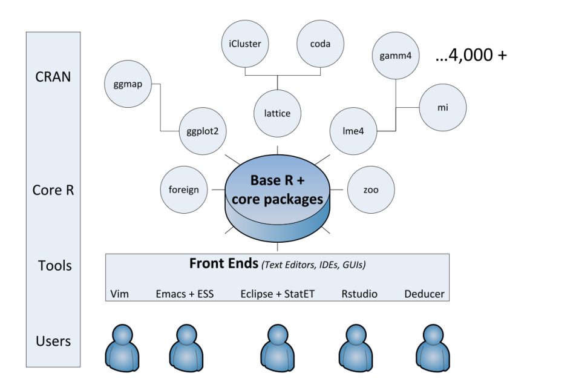

- `dplyr`
- `lme4`
- `ggplot2`

### R creating objects

- Everything in R is an **object**.
- To create a object use the following syntax:

```r
x = 20
x <- 20 # this is a comment and '<-' produces the same result as '='
x = c(10,20,30) # combining values
```

Use functions for the objects:

```r
mean(x)
```

```
[1] 20
```

```r
var(x)
```

```
[1] 100
```

```r
sum(x)
```

```
[1] 60
```

### Data Types and Structures

R has many data structures. These include:

- **atomic vectors**
- list
- **matrix**
- **data frame**
- arrays

### Atomic Vectors

- A vector is the most common and basic data structure in R

```r
x = c(1,2,3,4,5) #numerical vector
y =  c("Sarah", "Tracy", "Jon") # vector of character
y = c(TRUE, TRUE, FALSE, FALSE) # logical vector
```

### Data Types and Structures

### Matrix and Data frame

- The best way to understand what is a `matrix` and a `data frame` is understanding how the vectors could be grouped.
- Ex:

```r
x = c(1,2)
y = c(1,3)
z = c("Brazil", "Argentina")

matrix(c(x,y),2,2)
```

```
     [,1] [,2]
[1,]    1    1
[2,]    2    3
```

```r
data.frame(x,y,z)
```

```
  x y         z
1 1 1    Brazil
2 2 3 Argentina
```

### Genomic Data sets

```r
x = c("snp1","snp2", "snp3", "snp4", "snp5", "snp6")
y = c(1,1,2,2,3,3)
z = c(10,20,100,400,150,200)
ind1 = c("AA", "AA", "aa", "Aa", "aa", "AA")
ind2 = c("AA", "AA", "aa", "Aa", "AA", "AA")
ind3 = c("Aa", "AA", "aa", "Aa", "Aa", "aa")
ind4 = c("aa", "AA", "Aa", "aa", "AA", "AA")

snp_data = data.frame(name = x,chr = y,pos = z,ind1,ind2,ind3,ind4)
snp_data
```

```
  name chr pos ind1 ind2 ind3 ind4
1 snp1   1  10   AA   AA   Aa   aa
2 snp2   1  20   AA   AA   AA   AA
3 snp3   2 100   aa   aa   aa   Aa
4 snp4   2 400   Aa   Aa   Aa   aa
5 snp5   3 150   aa   AA   Aa   AA
6 snp6   3 200   AA   AA   aa   AA
```

### Subsetting Data

- Select only snp1:

```r
snp_data[1,] # selection the first row
```

```
  name chr pos ind1 ind2 ind3 ind4
1 snp1   1  10   AA   AA   Aa   aa
```

- Select only ind1:

```r
snp_data[,4] # selection the col indicating ind 1
```

```
[1] AA AA aa Aa aa AA
Levels: aa Aa AA
```

- Delete rows and col:

```r
snp_data[,-2] # deleting the chr info
```

```
  name pos ind1 ind2 ind3 ind4
1 snp1  10   AA   AA   Aa   aa
2 snp2  20   AA   AA   AA   AA
3 snp3 100   aa   aa   aa   Aa
4 snp4 400   Aa   Aa   Aa   aa
5 snp5 150   aa   AA   Aa   AA
6 snp6 200   AA   AA   aa   AA
```

### Population Genetics Summary

- snpReady package
- https://cran.r-project.org/web/packages/snpReady/index.html

```r
library(snpReady)
data("maize.hyb")
class(maize.hyb)
```

```
[1] "matrix"
```

```r
dim(maize.hyb) # ind x markers
```

```
[1]  50 492
```

```r
maize.hyb[1:5,1:5]
```

```
   Affx.91024531 Affx.91384967 Affx.91154529 Affx.90613320 Affx.90669273
A1             1             0             0             2             2
A2             2             0             0             1             1
A3             2             0             1             2             2
A4             2             0             1             2             2
A5             2             0             0             2             2
```

### Population Genetics Summary

## Allele Frequencie

\[ f(A_1) = p_j = \dfrac{\#A_1}{2N} \]

\[ f(A_2) = q_j = 1-p_j \]

```r
nA1 = sum(maize.hyb[,1])
N = length(maize.hyb[,1])
p_1 = nA1/(2*N)
q_1 = 1-p_1
p_1
```

```
[1] 0.93
```

```r
q_1
```

```
[1] 0.07
```

### Population Genetics Summary

## Allele Frequencie

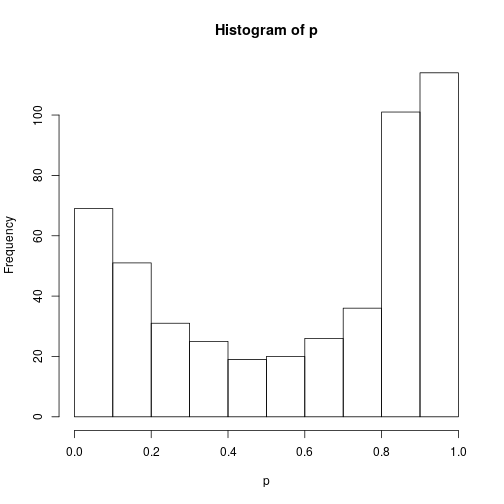

```r
p <- colMeans(maize.hyb, na.rm = T)/2
q=1-p
hist(p)
```

### Population Genetics Summary

## Observed and expected heterozygosity

\[ H_0= \dfrac{\#H_j}{N} \]

\[ H_e = 2p_jq_j \]

```r
nA12 = sum(maize.hyb[,1]==1)
N = length(maize.hyb[,1])
h0_1 = nA12/N #obs Het
h0_1
```

```
[1] 0.1
```

```r
he_1 =2* p_1 * q_1 #exp het
he_1
```

```
[1] 0.1302
```

```r
Hobs <- colMeans(maize.hyb== 1, na.rm = T)
Hesp <- 2*p*q
```

### Population Genetics Summary

## Checking HWE

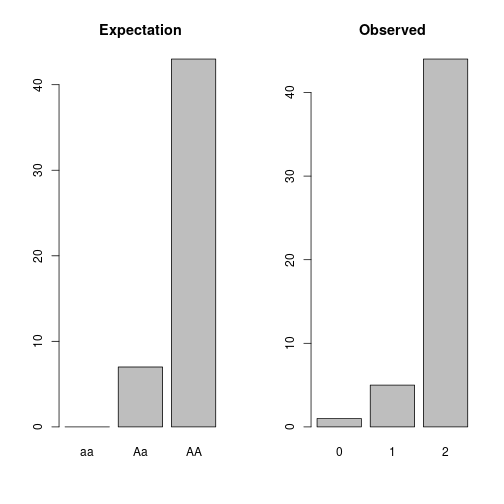

```r
Expectation = c(aa =q_1^2, Aa = 2*p_1*q_1, AA=p_1^2) * N
par(mfrow=c(1,2))
barplot(round(Expectation), main="Expectation")
barplot(table(maize.hyb[,1]), main="Observed")
```

```r
chisq.test(table(maize.hyb[,1]),p=Expectation/N) #H0:HWE vs. Ha:noHWE
```

```
    Chi-squared test for given probabilities

data:  table(maize.hyb[, 1])
X-squared = 2.6901, df = 2, p-value = 0.2605
```

### Population Genetics Summary

## Markers Metrics

```r
pop.gen <- popgen(M = maize.hyb)

head(pop.gen$whole$Markers)
```

```
                 p    q  MAF   He   Ho   GD  PIC Miss chiSq      pval
Affx.91024531 0.93 0.07 0.07 0.13 0.10 0.13 0.12    0 2.690 0.1009760
Affx.91384967 0.06 0.94 0.06 0.11 0.12 0.11 0.11    0 0.204 0.6517411
Affx.91154529 0.02 0.98 0.02 0.04 0.04 0.04 0.04    0 0.021 0.8852577
Affx.90613320 0.60 0.40 0.40 0.48 0.48 0.48 0.36    0 0.000 1.0000000
Affx.90669273 0.87 0.13 0.13 0.23 0.26 0.23 0.20    0 1.116 0.2906959
Affx.91248776 0.23 0.77 0.23 0.35 0.42 0.35 0.29    0 1.726 0.1889817
```

### Population Genetics Summary

## Genotype Metrics

```r
head(pop.gen$whole$Genotypes)
```

```
     Ho     Fi
A1 0.25  0.008
A2 0.25 -0.016
A3 0.32 -0.303
A4 0.29 -0.180
A5 0.24  0.041
A6 0.26 -0.057
```

### Population Genetics Summary

## Population Metrics

```r
pop.gen$whole$Population
```

```
     mean lower upper
GD   0.25  0.02  0.50
PIC  0.21  0.02  0.38
MAF  0.17  0.01  0.50
Ho   0.27  0.20  0.33
F   -0.08 -0.34  0.20
```

### Population Genetics Summary

## Variability Metrics

```r
pop.gen$whole$Variability
```

```
                    estimate
Ne                   -312.58
Va                    122.22
Vd                     40.27
number.of.genotypes    50.00
number.of.markers     492.00
```

### Population Genetics Summary

## Homework/Quiz 1

### Objectives:

- Most important: get experience with R !
- Estimate population genetic parameters in a real data set.
- Interpret the results in a breeding program context.

### Population Genetics Summary

## Homework/Quiz 1

1) Read the paper and download the genotyping data for the whole set of accessions (Additional File 2) : https://bmcgenomics.biomedcentral.com/articles/10.1186/s12864-017-3805-4

- Save the file in a `csv` format.
- Use the `read.csv` command in R to import the data.

2) Produce a table similar to the Table 1 in the paper:

- Use the concepts of subsetting data presented in the class.
- Have you tried the `dplyr` package?

3) Transform the data in the 012 format

- Function `raw.data` from the `snpReady` package
- Use the arguments `call.rate = 0.1` and `maf=0.0001` to mantain all markers.

```r
snp012 = raw.data(snp.data, frame = "wide",
               base=TRUE,  imput = FALSE,
               call.rate = 0.1, maf=0.0001)
```

### Population Genetics Summary

## Homework/Quiz 1

4) Describe the markers information. You can use graphics to help you.

- Any marker with `maf<0.05`?
- Any marker with a high number of missing data?
- Check the Hardy-Weinberg equilibrium statistic for each marker.

5) Compute the population genetic values implemented in the `snpReady` package. Compare the values with the results presented in the original paper. Discuss the global value of H0 and inbreeding coefficient computed.

6) Based on this data set, try to compute another population metric that might be important to describe the population. It may be one of the metrics already described in the paper (e.g., Fst, dendrogram, linkage disequilibrium) or any other that you judge important. Show the codes used to compute it and discuss an eventual importance of the proposed analysis in the context of the paper.

### Population Genetics Summary

- Ex: I computed a PCA analysis based on the pedigree and noted similar groups that were presented in the paper.

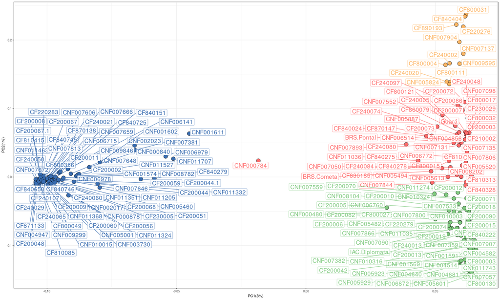

### Population Genetics Summary

## Homework/Quiz 1

7) In one paragraph, describe how the results presented in the original paper could help the breeding programs.

### General Tips

- If you have experience in R, I would recommend you to write your report using the RMarkdown.
- You can use the same packages used in the original paper or in the class, but we are encouraging you to **go beyond**! R is rich in packages and methodologies for Population Genetic studies!
- The R community is strong and active on the internet. Do not be afraid to use Google and ask for help!